# Statistical analyses

Author 1

2023-10-24

Hello, reader! Thank you for your interest in this work.

Let me guide you through the steps taken to conduct the statistical analyses reported on our paper.

## Preparation

**Loading libraries**

Here are the libraries that we are going to employ. If you have not already, remember to install them via `install.packages()` first:

```r
library(tidyverse)
library(corrplot)
library(ggstatsplot)
library(lme4)
library(caret)
library(car)
library(broom)
library(glmmTMB)
library(DHARMa)
library(mosaic)
library(MASS)
library(nlme)
library(nnet)
library(lmtest)
library(glmnet)
library(visreg)
library(mgcv)
library(ggeffects)
library(ROCR)
library(broom.mixed)
library(boot)
library(parameters)
```

**Loading data sets**

Next, we are going to load the data sets obtained after computing the measures needed for our model with Python.

```r
# ==== 1. STUDENT PREFERENCES ====
student_preferences <- read_csv('Data/participant_responses.csv')

# ==== 2. TEXT AND FULL ERROR ANALYSES ====
full_text_analysis <- read_csv('Data/full_measures.csv')
full_error_measures <- read_csv('Data/full_error_measures.csv')

# ==== 3. TEXT AND TRACKED ERROR ANALYSIS ====
tracked_text_analysis <- read_csv('Data/tracked_error_measures.csv')
```

**RQ1: WHAT TYPES OF WCF, IF ANY, MOST EFFECTIVELY ENHANCE THE LEXICAL ACCURACY OF ADVANCED SFL LEARNERS? DO THEY ACHIEVE THIS IMPROVEMENT AT THE COST OF LEXICAL COMPLEXITY?**

```r
# 1.1. === DATA PREPARATION ===

full_text_analysis <- full_join(full_text_analysis, full_error_measures, by = "error")
rows_to_remove <- c(65, 67, 187, 195)
full_text_analysis <- full_text_analysis[-rows_to_remove,]

lmm.df <- full_text_analysis %>% dplyr::select(participant_ID = participant_ID.x,
                                               text_ID = text_ID.x,
                                               TextNum = TextNum.x,
                                               fb_type = fb_type.x,
                                               word_count = Total,
                                               lexical_density = `Lexical density`,
                                               FreqC1, FreqC2, rttr, mtld, error_rate)

lmm.df.wide <- lmm.df %>%
  group_by(text_ID, fb_type) %>%
  summarise(count = n()) %>%
  pivot_wider(names_from = fb_type, values_from = count,
              names_prefix = "fb_count_")

lmm.df.wide[is.na(lmm.df.wide)] <- 0

lmm.df <- full_join(lmm.df, lmm.df.wide, by = "text_ID")

lmm.df <- lmm.df %>%
  mutate(FreqC = FreqC1 + FreqC2) %>%
  dplyr::select(-text_ID, -fb_type, -FreqC1, -FreqC2)

lmm.df <- distinct(lmm.df)

lmm.df <- lmm.df %>%
  arrange(participant_ID, TextNum) %>%
  group_by(participant_ID) %>%
  mutate(across(starts_with("fb_count_"), \(x) lag(x, default = 0))) %>%
  ungroup() %>%
  arrange(participant_ID, TextNum)

lmm.df <- lmm.df %>%
  mutate(across(starts_with("fb_count_"), ~ . / word_count, .names = "rate_{.col}"))

lmm.df <- lmm.df %>%
  dplyr::select(-word_count, -c("fb_count_D.M.":"fb_count_R"))

lmm.df$participant_ID <- as.factor(lmm.df$participant_ID)
lmm.df$TextNum <- as.factor(lmm.df$TextNum)

lmm.df$rate_fb_count_D.M. <- scale(lmm.df$rate_fb_count_D.M.)
lmm.df$rate_fb_count_D.N.M <- scale(lmm.df$rate_fb_count_D.N.M)
lmm.df$rate_fb_count_I.L. <- scale(lmm.df$rate_fb_count_I.L.)
lmm.df$rate_fb_count_I.M. <- scale(lmm.df$rate_fb_count_I.M.)
lmm.df$rate_fb_count_None <- scale(lmm.df$rate_fb_count_None)
lmm.df$rate_fb_count_R <- scale(lmm.df$rate_fb_count_R)


# 1.2. === GENERALIZED LINEAR MIXED EFFECTS MODEL WITH BETA DISTRIBUTION ===

# 1.2.1. Fitting and interpreting the model

model.RQ1.errorRate <- glmmTMB(
  error_rate ~ rate_fb_count_D.M. + rate_fb_count_D.N.M + rate_fb_count_I.L. +
    rate_fb_count_I.M. + rate_fb_count_None + rate_fb_count_R + (1|participant_ID) + (1|TextNum),
  data = lmm.df, family = beta_family())

summary(model.RQ1.errorRate)
```

```
##  Family: beta  ( logit )
## Formula:
## error_rate ~ rate_fb_count_D.M. + rate_fb_count_D.N.M + rate_fb_count_I.L. +
##     rate_fb_count_I.M. + rate_fb_count_None + rate_fb_count_R +
##     (1 | participant_ID) + (1 | TextNum)
## Data: lmm.df
##
##      AIC      BIC   logLik deviance df.resid
##   -426.0   -401.7    223.0   -446.0       74
##
## Random effects:
##
## Conditional model:
##  Groups         Name        Variance Std.Dev.
##  participant_ID (Intercept) 0.05076  0.2253
##  TextNum        (Intercept) 0.04462  0.2112
## Number of obs: 84, groups:  participant_ID, 21; TextNum, 4
##
## Dispersion parameter for beta family ():  142
##
## Conditional model:
##                      Estimate Std. Error z value Pr(>|z|)
## (Intercept)         -3.250170   0.127209 -25.550   <2e-16 ***
## rate_fb_count_D.M.  -0.008214   0.069573  -0.118   0.9060
## rate_fb_count_D.N.M  0.050668   0.101664   0.498   0.6182
## rate_fb_count_I.L.  -0.117682   0.059224  -1.987   0.0469 *
## rate_fb_count_I.M.  -0.012433   0.066139  -0.188   0.8509
## rate_fb_count_None   0.001702   0.060836   0.028   0.9777
## rate_fb_count_R      0.113500   0.069746   1.627   0.1037
## ---
## Signif. codes:  0 '***' 0.001 '**' 0.01 '*' 0.05 '.' 0.1 ' ' 1
```

```r
model_parameters(model.RQ1.errorRate)
```

```
## # Fixed Effects
##
## Parameter           | Coefficient |   SE |         95% CI |      z |      p
## ---------------------------------------------------------------------------
## (Intercept)         |       -3.25 | 0.13 | [-3.50, -3.00] | -25.55 | < .001
## rate fb count D M   |   -8.21e-03 | 0.07 | [-0.14,  0.13] |  -0.12 | 0.906
## rate fb count D N M |        0.05 | 0.10 | [-0.15,  0.25] |   0.50 | 0.618
## rate fb count I L   |       -0.12 | 0.06 | [-0.23,  0.00] |  -1.99 | 0.047
## rate fb count I M   |       -0.01 | 0.07 | [-0.14,  0.12] |  -0.19 | 0.851
## rate fb count None  |    1.70e-03 | 0.06 | [-0.12,  0.12] |   0.03 | 0.978
## rate fb count R     |        0.11 | 0.07 | [-0.02,  0.25] |   1.63 | 0.104
##
## # Dispersion
##
## Parameter   | Coefficient |          95% CI
## -------------------------------------------
## (Intercept) |      142.00 | [90.82, 222.01]
##
## # Random Effects Variances
##
## Parameter                      | Coefficient |       95% CI
## -----------------------------------------------------------
## SD (Intercept: participant_ID) |        0.23 | [0.09, 0.55]
## SD (Intercept: TextNum)        |        0.21 | [0.08, 0.56]
```

```r
model_parameters(model.RQ1.errorRate, exponentiate = TRUE)
```

```
## # Fixed Effects
##
## Parameter           | Coefficient |       SE |       95% CI |      z |      p
## -----------------------------------------------------------------------------
## (Intercept)         |        0.04 | 4.93e-03 | [0.03, 0.05] | -25.55 | < .001
## rate fb count D M   |        0.99 |     0.07 | [0.87, 1.14] |  -0.12 | 0.906
## rate fb count D N M |        1.05 |     0.11 | [0.86, 1.28] |   0.50 | 0.618
## rate fb count I L   |        0.89 |     0.05 | [0.79, 1.00] |  -1.99 | 0.047
## rate fb count I M   |        0.99 |     0.07 | [0.87, 1.12] |  -0.19 | 0.851
## rate fb count None  |        1.00 |     0.06 | [0.89, 1.13] |   0.03 | 0.978
## rate fb count R     |        1.12 |     0.08 | [0.98, 1.28] |   1.63 | 0.104
##
## # Dispersion
##
## Parameter   | Coefficient |          95% CI
## -------------------------------------------
## (Intercept) |      142.00 | [90.82, 222.01]
##
## # Random Effects Variances
##
## Parameter                      | Coefficient |       95% CI
## -----------------------------------------------------------
## SD (Intercept: participant_ID) |        0.23 | [0.09, 0.55]
## SD (Intercept: TextNum)        |        0.21 | [0.08, 0.56]
```

```r
# 1.2.2 Checking for overdispersion
overdisp <- residuals(model.RQ1.errorRate, type = "pearson")^2
overdisp_ratio <- sum(overdisp) / df.residual(model.RQ1.errorRate)
overdisp_ratio
```

```
## [1] 0.006418292
```

```r
car::vif(lm(error_rate ~ rate_fb_count_D.M. + rate_fb_count_D.N.M + rate_fb_count_I.L. + rate_fb_count_I.M. + rate_fb_count_None + rate_fb_count_R, data = lmm.df))
```

```
##  rate_fb_count_D.M. rate_fb_count_D.N.M  rate_fb_count_I.L.  rate_fb_count_I.M.
##            1.648948            2.908050            1.386942            1.794983
##  rate_fb_count_None     rate_fb_count_R
##            1.716882            2.075322
```

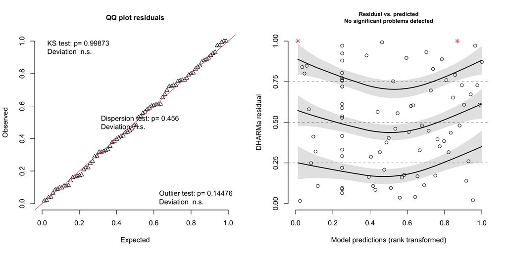

```r
# 1.2.3 Visualizing fitted values vs. observed values
#plot(fitted(model.RQ1.errorRate), lmm.df$error_rate, xlab = "Fitted Values", ylab = "Observed Values")

# 1.2.4. Checking residuals vs. fitted values
#plot(fitted(model.RQ1.errorRate), resid(model.RQ1.errorRate), xlab = "Fitted Values", ylab = "Residuals")

# 1.2.5. Checking the Q-Q plot of the residuals
#qqnorm(resid(model.RQ1.errorRate))
#qqline(resid(model.RQ1.errorRate))

# 1.2.6. Interpreting residuals

##   Florian Hartig (2022). DHARMa: Residual Diagnostics for Hierarchical
##   (Multi-Level / Mixed) Regression Models. R package version 0.4.6.
##   http://florianhartig.github.io/DHARMa/

par(mfrow = c(1, 2))
a <- plotQQunif(model.RQ1.errorRate)
b <- plotResiduals(model.RQ1.errorRate)
```

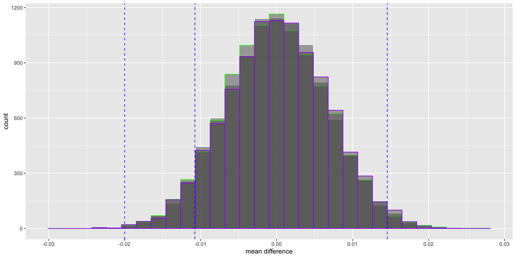

```r
par(mfrow = c(1, 1))

# 1.3. === PERMUTATION TESTS ON THE EQUALITY OF MEANS OF LEXICAL COMPLEXITY MEASURES ===

# 1.3.1. Calculate the observed difference in means

avg.FreqC <- mean(FreqC ~ TextNum, data = lmm.df) %>%
  diff()
avg.mtld <- mean(mtld ~ TextNum, data = lmm.df) %>%
  diff()
avg.density <- mean(lexical_density ~ TextNum, data = lmm.df) %>%
  diff()

# 1.3.2. Create a randomization distribution of all the differences in means under the null hypothesis
set.seed(17)
FreqC_null <- do(10000) * mean(FreqC ~ shuffle(TextNum), data = lmm.df) %>%
  diff()
set.seed(17)
mtld_null <- do(10000) * mean(mtld ~ shuffle(TextNum), data = lmm.df) %>%
  diff()
set.seed(17)
density_null <- do(10000) * mean(lexical_density ~ shuffle(TextNum), data = lmm.df) %>%
  diff()

# 1.3.3. Plot the randomization distribution
p <- ggplot(data = FreqC_null) +
  geom_histogram(mapping = aes(x = X2), alpha = 0.5, colour = "white") +
  geom_histogram(mapping = aes(x = X3), alpha = 0.5, colour = "green") +
  geom_histogram(mapping = aes(x = X4), alpha = 0.5, colour = "purple") +
  xlab("mean difference")

q <- ggplot(data = mtld_null) +
  geom_histogram(mapping = aes(x = X2), alpha = 0.5, colour = "white") +
  geom_histogram(mapping = aes(x = X3), alpha = 0.5, colour = "green") +
  geom_histogram(mapping = aes(x = X4), alpha = 0.5, colour = "purple") +
  xlab("mean difference")

r <- ggplot(data = density_null) +
  geom_histogram(mapping = aes(x = X2), alpha = 0.5, colour = "white") +
  geom_histogram(mapping = aes(x = X3), alpha = 0.5, colour = "green") +
  geom_histogram(mapping = aes(x = X4), alpha = 0.5, colour = "purple") +
  xlab("mean difference")

# 1.3.4. Superimpose a line indicating the observation
p + geom_vline(xintercept = avg.FreqC, linetype = 2, colour = "blue")
```

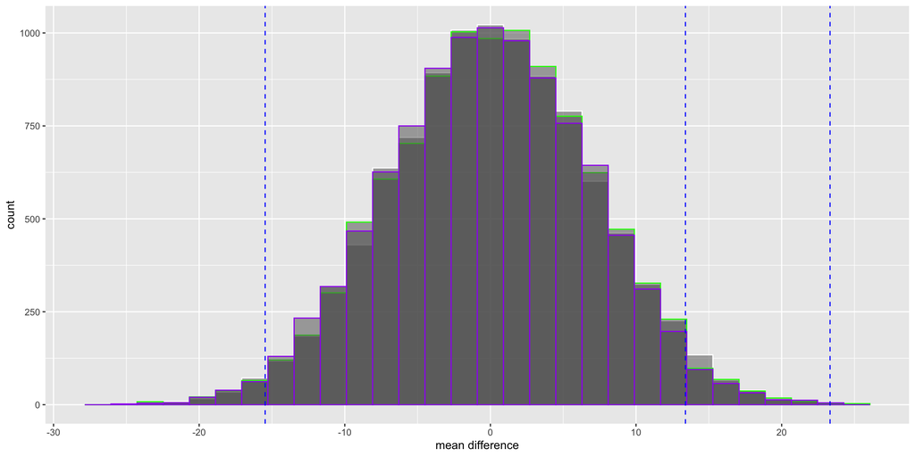

```r
q + geom_vline(xintercept = avg.mtld, linetype = 2, colour = "blue")
```

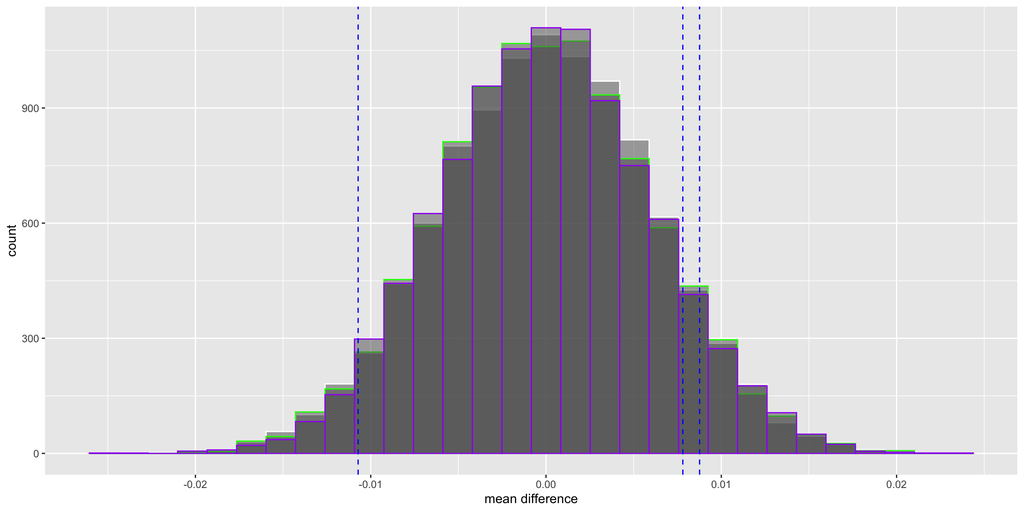

```r
r + geom_vline(xintercept = avg.density, linetype = 2, colour = "blue")
```

```r
# 1.3.6. Calculate the proportion of simulated differences in means as or more extreme than the observed

prop_FreqC_X2 <- mean(FreqC_null$X2 >= avg.FreqC["2"])
prop_FreqC_X3 <- mean(FreqC_null$X3 >= avg.FreqC["3"])
prop_FreqC_X4 <- mean(FreqC_null$X4 >= avg.FreqC["4"])

prop_mtld_X2 <- mean(mtld_null$X2 >= avg.mtld["2"])
prop_mtld_X3 <- mean(mtld_null$X3 >= avg.mtld["3"])
prop_mtld_X4 <- mean(mtld_null$X4 >= avg.mtld["4"])

prop_density_X2 <- mean(density_null$X2 >= avg.density["2"])
prop_density_X3 <- mean(density_null$X3 >= avg.density["3"])
prop_density_X4 <- mean(density_null$X4 >= avg.density["4"])

# 1.3.7. Apply BH correction

p_values_FreqC <- c(prop_FreqC_X2, prop_FreqC_X3, prop_FreqC_X4)
p_values_mtld <- c(prop_mtld_X2, prop_mtld_X3, prop_mtld_X4)
p_values_density <- c(prop_density_X2, prop_density_X3, prop_density_X4)

p_values_FreqC_corrected <- p.adjust(p_values_FreqC, method = "BH", n = length(p_values_FreqC))
p_values_mtld_corrected <- p.adjust(p_values_mtld, method = "BH", n = length(p_values_mtld))
p_values_density_corrected <- p.adjust(p_values_density, method = "BH", n = length(p_values_density))

p_values_FreqC_corrected
```

```
## [1] 0.9988 0.0381 0.9988
```

```r
p_values_mtld_corrected
```

```
## [1] 0.0003 0.9872 0.0333
```

```r
p_values_density_corrected
```

```
## [1] 0.1491 0.1491 0.9661
```

**RQ2: HOW DO THE DIFFERENT WCF FORMATS THE TEACHER PROVIDES RELATE TO THE VARIOUS TYPES OF LEXICAL ERRORS COMMITTED BY THE LEARNERS AND THEIR SUBSEQUENT MENDING OR REPETITION?**

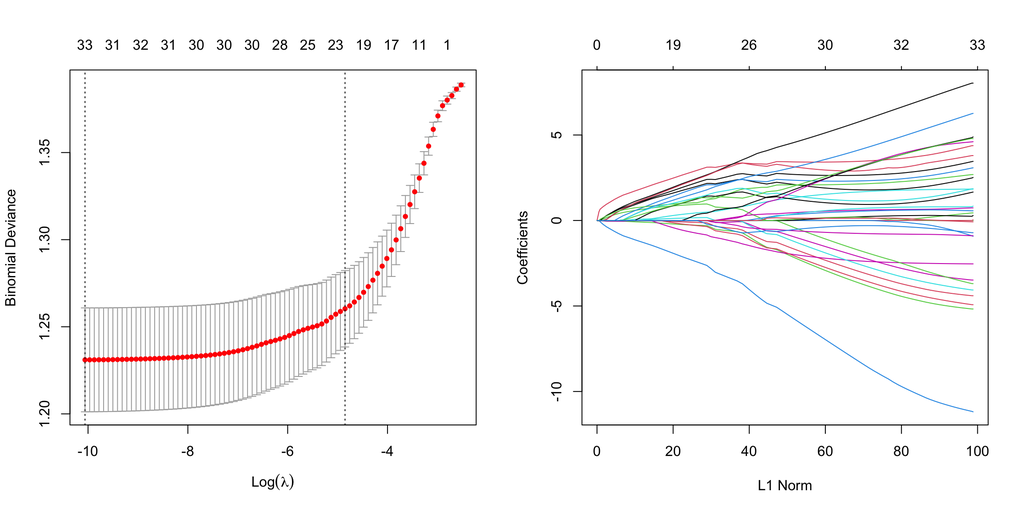

```r
# === 2.1. DATA PREPARATION ===

# 2.1.1. Join the error and text analyses with the questionnaire responses
preferences_and_performance <- full_join(student_preferences, tracked_text_analysis, by = "participant_ID")


# 2.1.2. Keep only relevant columns
preferences_and_performance <- preferences_and_performance[, c("participant_ID",
                                                               "age",
                                                               "sex",
                                                               "country",
                                                               "background",
                                                               "years_speak_spa",
                                                               "fb_importance",
                                                               "fb_satisfaction",
                                                               "freq_seek_additional_info",
                                                               "how_much_fb_helps_learn",
                                                               "fb_1_clarity", "fb_1_usefulness", "likes_fb_1",
                                                               "fb_2_clarity", "fb_2_usefulness", "likes_fb_2",
                                                               "fb_3_clarity", "fb_3_usefulness", "likes_fb_3",
                                                               "fb_4_clarity", "fb_4_usefulness", "likes_fb_4",
                                                               "fb_5_clarity", "fb_5_usefulness", "likes_fb_5",
                                                               "fb_6_clarity", "fb_6_usefulness", "likes_fb_6",
                                                               "fb_7_clarity", "fb_7_usefulness", "likes_fb_7",
                                                               "text_ID",
                                                               "error",
                                                               "error_type",
                                                               "fb_type",
                                                               "pass_solution_reps", "fail_solution_reps", "error_reps",
                                                               "TextNum",
                                                               "error_rate", "error_rate_per_type", "fb_rate_per_type",
                                                               "FreqA1", "FreqA2", "FreqB1", "FreqB2", "FreqC1", "FreqC2",
                                                               "msttr", "mattr", "ttr", "rttr", "cttr",
                                                               "mtld", "hdd", "Herdan", "Summer", "Dugast", "Maas",
                                                               "outcome")]


# === 2.2. LASSO REGRESSION ===

# 2.2.1. Collapse the "Both fixed and repeated" and "Fixed inadequately" levels to simplify the model and upsample the data to address class imbalance

preferences_and_performance$outcome[preferences_and_performance$outcome == "Both fixed and repeated"] <- "Fixed"
preferences_and_performance$outcome[preferences_and_performance$outcome == "Both fixed and repeated"] <- "Repeated"
preferences_and_performance$outcome[preferences_and_performance$outcome == "Fixed inadequately"] <- "Repeated"

preferences_and_performance$fb_type <- as.factor(preferences_and_performance$fb_type)
preferences_and_performance$fb_type <- relevel(preferences_and_performance$fb_type, ref = "No WCF")
preferences_and_performance$error_type <- as.factor(preferences_and_performance$error_type)
preferences_and_performance$outcome <- as.factor(preferences_and_performance$outcome)
preferences_and_performance$participant_ID <- as.factor(preferences_and_performance$participant_ID)

set.seed(17)
up.preferences_and_performance <- upSample(preferences_and_performance[,-60],
                                           preferences_and_performance$outcome,
                                           yname="outcome")

up.preferences_and_performance <- up.preferences_and_performance %>%
  dplyr::select(outcome, fb_type, error_type, participant_ID)

# 2.2.2. Fit the model with the appropriate lambda using cross-validation

lasso.data <- up.preferences_and_performance
lasso.data$fb_type <- relevel(lasso.data$fb_type, ref = "No WCF")

lasso.data$outcome_binary <- ifelse(lasso.data$outcome == "Fixed", 1, 0)

X <- model.matrix(~ error_type * fb_type, data = lasso.data)

CV.model.RQ2.outcome <- cv.glmnet(X,
                                  lasso.data$outcome_binary,
                                  family = "binomial",
                                  alpha = 1)
par(mfrow = c(1, 2))
plot(CV.model.RQ2.outcome)
plot(CV.model.RQ2.outcome$glmnet.fit)
```

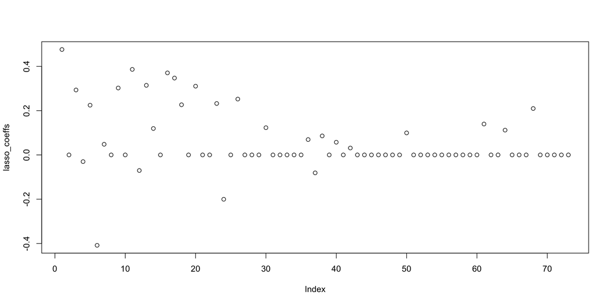

```r
par(mfrow = c(1, 1))
lambda.1se <- CV.model.RQ2.outcome$lambda.1se

model.RQ2.outcome <- glmnet(X,
                            lasso.data$outcome_binary,
                            alpha = 1,
                            lambda = lambda.1se)

lasso_coeffs <- coef(model.RQ2.outcome, s = "lambda.1se")
plot(lasso_coeffs)
```

```r
model.RQ2.outcome
```

```
##
## Call:  glmnet(x = X, y = lasso.data$outcome_binary, alpha = 1, lambda = lambda.1se)
##
##   Df  %Dev   Lambda
## 1 27 13.03 0.007822
```

```r
lasso_coeffs
```

```
## 73 x 1 sparse Matrix of class "dgCMatrix"
##                                                                        s1
## (Intercept)                                                    0.47613942
## (Intercept)                                                    .
## error_typeCreation                                             0.29336455
## error_typeDetermination                                       -0.03020324
## error_typeEllipsis                                             0.22465015
## error_typeExcess word(s)                                      -0.40839296
## error_typeGender                                               0.04803681
## error_typeGovernment                                           .
## error_typeNumber                                               0.30224163
## error_typeOrder                                                .
## error_typePronoun                                              0.38631845
## error_typeSubstitution                                        -0.07043546
## error_typeSynthesis                                            0.31432931
## fb_typeDirect metalinguistic WCF                               0.11930590
## fb_typeDirect non-metalinguistic WCF                           .
## fb_typeIndirect metalinguistic WCF                             0.37057162
## fb_typeLocated indirect WCF                                    0.34717506
## fb_typeReformulation                                           0.22656724
## error_typeCreation:fb_typeDirect metalinguistic WCF            .
## error_typeDetermination:fb_typeDirect metalinguistic WCF       0.31049389
## error_typeEllipsis:fb_typeDirect metalinguistic WCF            .
## error_typeExcess word(s):fb_typeDirect metalinguistic WCF      .
## error_typeGender:fb_typeDirect metalinguistic WCF              0.23225313
## error_typeGovernment:fb_typeDirect metalinguistic WCF         -0.20036534
## error_typeNumber:fb_typeDirect metalinguistic WCF              .
## error_typeOrder:fb_typeDirect metalinguistic WCF               0.25225726
## error_typePronoun:fb_typeDirect metalinguistic WCF             .
## error_typeSubstitution:fb_typeDirect metalinguistic WCF        .
## error_typeSynthesis:fb_typeDirect metalinguistic WCF           .
## error_typeCreation:fb_typeDirect non-metalinguistic WCF        0.12294791
## error_typeDetermination:fb_typeDirect non-metalinguistic WCF   .
## error_typeEllipsis:fb_typeDirect non-metalinguistic WCF        .
## error_typeExcess word(s):fb_typeDirect non-metalinguistic WCF  .
## error_typeGender:fb_typeDirect non-metalinguistic WCF          .
## error_typeGovernment:fb_typeDirect non-metalinguistic WCF      .
## error_typeNumber:fb_typeDirect non-metalinguistic WCF          0.06932704
## error_typeOrder:fb_typeDirect non-metalinguistic WCF          -0.08105500
## error_typePronoun:fb_typeDirect non-metalinguistic WCF         0.08583749
```

[output cut: 20 more lines]

```
## error_typeOrder:fb_typeLocated indirect WCF                    .
## error_typePronoun:fb_typeLocated indirect WCF                  .
## error_typeSubstitution:fb_typeLocated indirect WCF             0.13958304
## error_typeSynthesis:fb_typeLocated indirect WCF                .
## error_typeCreation:fb_typeReformulation                        .
## error_typeDetermination:fb_typeReformulation                   0.11199273
## error_typeEllipsis:fb_typeReformulation                        .
## error_typeExcess word(s):fb_typeReformulation                  .
## error_typeGender:fb_typeReformulation                          .
## error_typeGovernment:fb_typeReformulation                      0.20960402
## error_typeNumber:fb_typeReformulation                          .
## error_typeOrder:fb_typeReformulation                           .
## error_typePronoun:fb_typeReformulation                         .
## error_typeSubstitution:fb_typeReformulation                    .
## error_typeSynthesis:fb_typeReformulation                       .
```

```r
new_X <- expand.grid(
  error_type = levels(lasso.data$error_type),
  fb_type = levels(lasso.data$fb_type)
)

# Number of parameters (non-zero coefficients in the model)
num_parameters <- sum(coef(model.RQ2.outcome) != 0)

# Deviance of the model
deviance <- deviance(model.RQ2.outcome)

# Number of observations
n_obs <- nobs(model.RQ2.outcome)

# Calculate AIC and BIC
AIC_value <- deviance + 2 * num_parameters
BIC_value <- deviance + log(n_obs) * num_parameters

# Likelihood ratio test for R^2
null_model <- glm(lasso.data$outcome_binary ~ 1, family = "binomial")
null_deviance <- deviance(null_model)

# Calculate R^2
R2 <- 1 - (deviance / null_deviance)

# Print the results
cat("AIC:", AIC_value, "\n")
```

```
## AIC: 221.2374
```

```r
cat("BIC:", BIC_value, "\n")
```

```
## BIC: 350.9703
```

```r
cat("R^2:", R2, "\n")
```

```
## R^2: 0.8431663
```

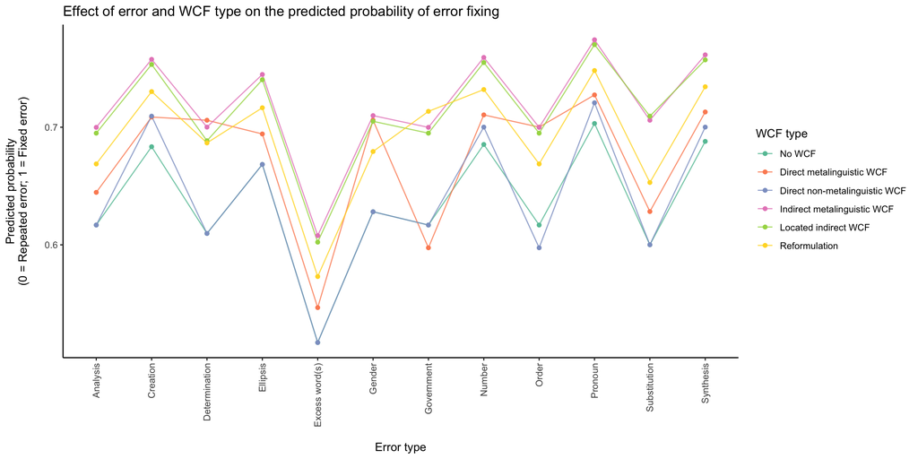

```r
new_X_matrix <- model.matrix(~ error_type * fb_type, data = new_X)
new_X_matrix <- new_X_matrix[, colnames(X)]

new_X$predicted_prob <- predict(model.RQ2.outcome,
                                newx = new_X_matrix,
                                s = "lambda.1se", type = "response")

new_X$predicted_prob <- plogis(new_X$predicted_prob)

m <- ggplot(new_X, aes(x = error_type,
                       y = predicted_prob,
                       color = fb_type,
                       group = fb_type)) +
  geom_line(alpha = 0.8) +
  geom_point() +
  labs(title = "Effect of error and WCF type on the predicted probability of error fixing",
       x = "\nError type",
       y = "Predicted probability\n(0 = Repeated error; 1 = Fixed error)\n") +
  theme_classic() +
  scale_color_brewer(palette = "Set2") +
  theme(axis.text.x = element_text(angle = 90, vjust = 0.5, hjust = 1)) +
  guides(color = guide_legend(title = "WCF type"))

m
```

```r
predicted_probs <- predict(model.RQ2.outcome, newx = model.matrix(~ error_type * fb_type, data = lasso.data), s = "lambda.1se", type = "response")

predicted_probs <- plogis(predicted_probs)

predicted_labels <- predict(model.RQ2.outcome, newx = model.matrix(~ error_type * fb_type, data = lasso.data), s = "lambda.1se", type = "response")

predicted_labels <- as.numeric(predicted_probs > 0.6097) # Median

conf_matrix <- table(Actual = lasso.data$outcome_binary, Predicted = predicted_labels)
conf_matrix
```

```
##       Predicted
## Actual   0   1
##      0 234 146
##      1 152 228
```

```r
accuracy <- sum(diag(conf_matrix)) / sum(conf_matrix)
accuracy
```

```
## [1] 0.6078947
```

```r
recall <- conf_matrix[2, 2] / sum(conf_matrix[2, ])
recall
```

```
## [1] 0.6
```

```r
precision <- conf_matrix[2, 2] / sum(conf_matrix[, 2])
precision
```

```
## [1] 0.6096257
```

```r
f1_score <- 2 * (precision * recall) / (precision + recall)
f1_score
```

```
## [1] 0.6047745
```

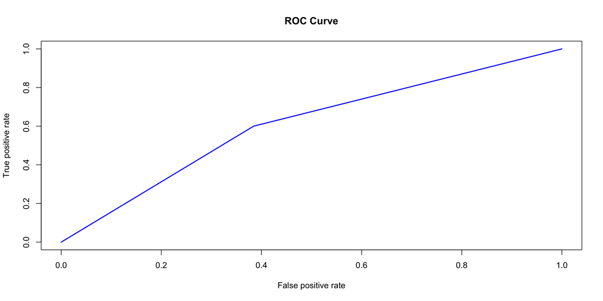

```r
prediction_obj <- prediction(predicted_labels, lasso.data$outcome_binary)
perf <- performance(prediction_obj, "tpr", "fpr")
plot(perf, main = "ROC Curve", col = "blue", lwd = 2)
```

```r
auc <- performance(prediction_obj, "auc")
auc_value <- unlist(slot(auc, "y.values"))
auc_value
```

```
## [1] 0.6078947
```

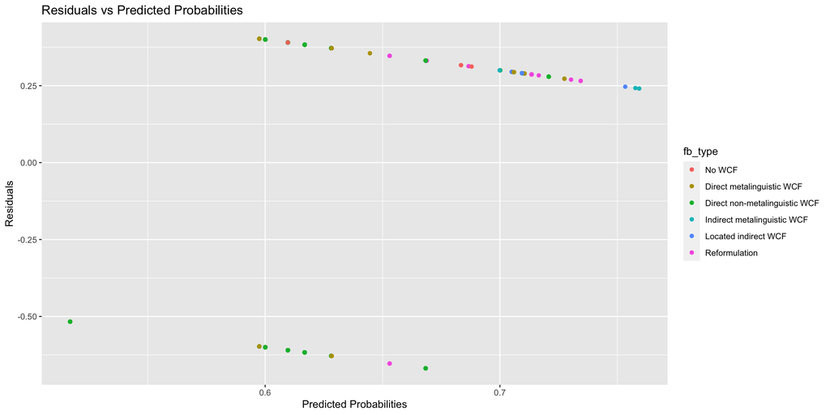

```r
residuals_lasso <- lasso.data$outcome_binary - predicted_probs

residual_data <- data.frame(predicted_probs = predicted_probs,
                            fb_type = lasso.data$fb_type,
                            residuals = residuals_lasso)

r <- ggplot(residual_data, aes(x = predicted_probs,
                               y = residuals_lasso,
                               color = fb_type)) +
  geom_point() +
  labs(title = "Residuals vs Predicted Probabilities",
       x = "Predicted Probabilities",
       y = "Residuals")

r
```

**RQ3: IS THERE A RELATIONSHIP BETWEEN LEARNER HABITS, BELIEFS, AND PREFERENCES REGARDING SPECIFIC TYPES OF WCF AND THEIR SUCCESSFUL APPROPRIATION? IF SO, WHICH ONE AND WHY?**

```r
# === 3.1. DATA PREPARATION ===

# 3.1.1. Create clarity, usefulness, and liking columns

errors_and_preferences <- full_join(student_preferences, full_error_measures, by = "participant_ID")

rename_map <- c("D.N.M" = "Direct non-metalinguistic WCF",
                "D.M." = "Direct metalinguistic WCF",
                "I.L." = "Located indirect WCF",
                "I.M." = "Located indirect WCF",
                "R" = "Reformulation",
                "None" = "No WCF")

errors_and_preferences$fb_type <- rename_map[errors_and_preferences$fb_type]

errors_and_preferences <- errors_and_preferences %>%
  rowwise() %>%
  mutate(clarity = case_when(
    fb_type == "Direct non-metalinguistic WCF" ~ fb_1_clarity,
    fb_type == "Direct metalinguistic WCF" ~ fb_2_clarity,
    fb_type == "Located indirect WCF" ~ fb_4_clarity,
    fb_type == "Indirect metalinguistic WCF" ~ fb_6_clarity,
    fb_type == "Reformulation" ~ fb_7_clarity,
    fb_type == "No WCF" ~ 0,
    TRUE ~ NA_real_
  ))

errors_and_preferences <- errors_and_preferences %>%
  rowwise() %>%
  mutate(usefulness = case_when(
    fb_type == "Direct non-metalinguistic WCF" ~ fb_1_usefulness,
    fb_type == "Direct metalinguistic WCF" ~ fb_2_usefulness,
    fb_type == "Located indirect WCF" ~ fb_4_usefulness,
    fb_type == "Indirect metalinguistic WCF" ~ fb_6_usefulness,
    fb_type == "Reformulation" ~ fb_7_usefulness,
    fb_type == "No WCF" ~ 0,
    TRUE ~ NA_real_
  ))

errors_and_preferences <- errors_and_preferences %>%
  rowwise() %>%
  mutate(liking = case_when(
    fb_type == "Direct non-metalinguistic WCF" ~ likes_fb_1,
    fb_type == "Direct metalinguistic WCF" ~ likes_fb_2,
    fb_type == "Located indirect WCF" ~ likes_fb_4,
    fb_type == "Indirect metalinguistic WCF" ~ likes_fb_6,
    fb_type == "Reformulation" ~ likes_fb_7,
    fb_type == "No WCF" ~ 0,
    TRUE ~ NA_real_
  ))


# 3.1.2. Combine with participant random effects

habits_beliefs_data <- errors_and_preferences %>%
  dplyr::select(participant_ID,
                fb_type,
                `Importance given to feedback` = fb_importance,
                `Seeking additional information on errors` = freq_seek_additional_info,
                `Perceived WCF format clarity` = clarity,
                `Perceived WCF format usefulness` = usefulness,
                `WCF format liking` = liking)

`Participant random effects` <- ranef(model.RQ1.errorRate)$cond$participant_ID

participant_random_effects_df <- as.data.frame(`Participant random effects`)
participant_random_effects_df$participant_ID <- rownames(participant_random_effects_df)
participant_random_effects_df <- participant_random_effects_df %>%
  rename(`Participant random effects (overall error rate)` = `(Intercept)`)

habits_beliefs_data <- merge(habits_beliefs_data, participant_random_effects_df, by = "participant_ID")

# 3.1.3. Combine with participant success rate
success_rate <- preferences_and_performance %>%
  group_by(participant_ID) %>%
  summarize(
    fixed_count = sum(outcome == "Fixed"),
    repeated_count = sum(outcome == "Repeated"),
    `Correction success rate (tracked errors)` = fixed_count / (fixed_count + repeated_count)
  )

success_rate <- success_rate %>%
  dplyr::select(-fixed_count, -repeated_count)

habits_beliefs_data <- left_join(habits_beliefs_data, success_rate, by = "participant_ID")

habits_beliefs_data <- distinct(habits_beliefs_data)


# --- 3.2. CORRELATIONS ---

cols.correlation <- habits_beliefs_data[, c(3:ncol(habits_beliefs_data))]

cols.correlation <- cols.correlation %>%
  select_if(is.numeric) %>%
  ungroup()

p_values <- matrix(NA, nrow = ncol(cols.correlation), ncol = ncol(cols.correlation))

for (i in 1:(ncol(cols.correlation) - 1)) {
  for (j in (i + 1):ncol(cols.correlation)) {
    # Extract columns for the correlation test
    x <- cols.correlation[[i]]
    y <- cols.correlation[[j]]

    # Perform the correlation test
    cor_test_result <- cor.test(x, y, method = "spearman", exact = FALSE)

    # Store the p-value in the matrix
    p_values[i, j] <- cor_test_result$p.value
    p_values[j, i] <- cor_test_result$p.value
  }
}

p_values
```

```
##              [,1]         [,2]         [,3]         [,4]         [,5]
## [1,]           NA 6.000657e-05 9.179619e-01 4.699313e-01 7.098730e-01
## [2,] 6.000657e-05           NA 5.090479e-01 4.126175e-01 6.308217e-01
## [3,] 9.179619e-01 5.090479e-01           NA 8.224062e-33 2.097864e-33
## [4,] 4.699313e-01 4.126175e-01 8.224062e-33           NA 1.433921e-37
## [5,] 7.098730e-01 6.308217e-01 2.097864e-33 1.433921e-37           NA
## [6,] 3.797843e-01 1.149849e-02 6.414830e-01 4.901860e-01 6.803790e-01
## [7,] 6.212639e-01 5.786683e-01 9.142767e-01 3.884867e-01 7.269421e-01
##              [,6]         [,7]
## [1,] 3.797843e-01 6.212639e-01
## [2,] 1.149849e-02 5.786683e-01
## [3,] 6.414830e-01 9.142767e-01
## [4,] 4.901860e-01 3.884867e-01
## [5,] 6.803790e-01 7.269421e-01
## [6,]           NA 1.978357e-11
## [7,] 1.978357e-11           NA
```

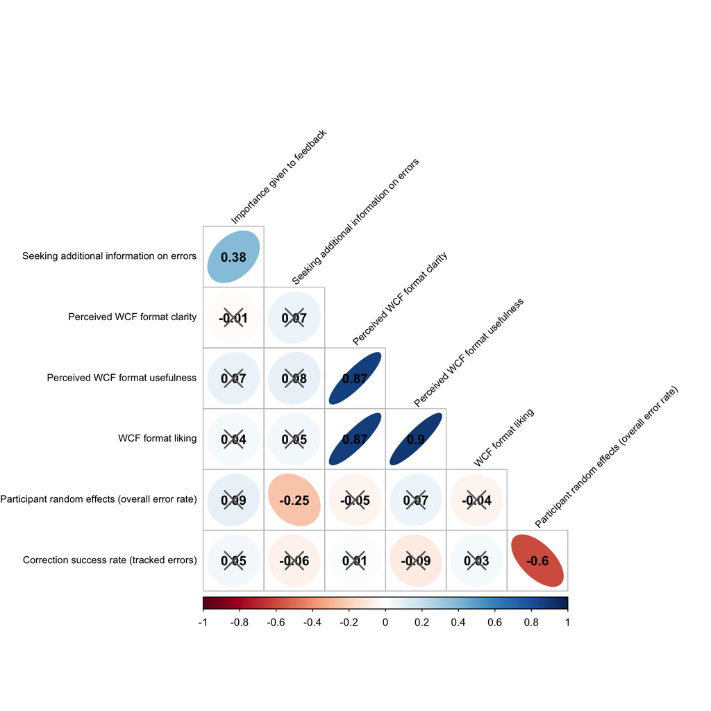

```r
corr.matrix <- cor(cols.correlation, use = "complete.obs", method = "spearman")
par(mfrow = c(1, 1))

# Create significance matrix with BH correction
p_values_adjusted <- p.adjust(p_values, method = "BH")
p_values_matrix <- matrix(p_values_adjusted, nrow = nrow(p_values), ncol = ncol(p_values))

p_values_matrix <- round(p_values_matrix, 3)

rownames(p_values_matrix) <- rownames(corr.matrix)
colnames(p_values_matrix) <- colnames(corr.matrix)

corrplot(corr.matrix, method = "ellipse", type = "lower", order = "original", diag = FALSE,
         mar=c(0,0,1,0), tl.cex = 0.75, tl.col = "black", tl.srt = 45, addCoef.col = "black",
         p.mat = p_values_matrix, sig.level = 0.05, insig = "pch", pch.col = "grey40")
```

```r
par(mfrow = c(1, 1))
```